# HW3

Daqi Chen

9/14/2020

```r
Ames5 <- read.csv("AmesTrain5.csv", header = TRUE, sep = ",")
sapply(Ames5, is.numeric)
```

```
##           Order           Price     LotFrontage         LotArea       LotConfig
##            TRUE            TRUE            TRUE            TRUE           FALSE
##      HouseStyle         Quality       Condition       YearBuilt     YearRemodel
##           FALSE            TRUE            TRUE            TRUE            TRUE
##       ExteriorQ       ExteriorC      Foundation      BasementHt       BasementC
##           FALSE           FALSE           FALSE           FALSE           FALSE
##     BasementFin   BasementFinSF BasementUnFinSF      BasementSF         Heating
##           FALSE            TRUE            TRUE            TRUE           FALSE
##       HeatingQC      CentralAir         FirstSF        SecondSF        GroundSF
##           FALSE           FALSE            TRUE            TRUE            TRUE
##   BasementFBath   BasementHBath        FullBath        HalfBath         Bedroom
##            TRUE            TRUE            TRUE            TRUE            TRUE
##        KitchenQ      TotalRooms      Fireplaces      GarageType      GarageCars
##           FALSE            TRUE            TRUE           FALSE            TRUE
##        GarageSF         GarageQ         GarageC      WoodDeckSF     OpenPorchSF
##            TRUE           FALSE           FALSE            TRUE            TRUE
## EnclosedPorchSF   ScreenPorchSF
##            TRUE            TRUE
```

Find the list of numeric variables in the dataset.

# Part 1: Build an initial “basic” model

## Inital model with all numerical variables

```r
Ames_1 = lm(Price~., data=Ames5[c(2:4, 7:10, 17:19, 23:30, 32, 33, 35, 36, 39:42)])
summary(Ames_1)
```

```
##
## Call:
## lm(formula = Price ~ ., data = Ames5[c(2:4, 7:10, 17:19, 23:30,
##     32, 33, 35, 36, 39:42)])
##
## Residuals:
##      Min       1Q   Median       3Q      Max
## -154.244  -15.603   -2.305   11.780  135.517
##
## Coefficients:
##                   Estimate Std. Error t value Pr(>|t|)
## (Intercept)     -1.485e+03  1.654e+02  -8.983  < 2e-16 ***
## LotFrontage      1.526e-01  3.637e-02   4.196 3.14e-05 ***
## LotArea          5.252e-04  9.327e-05   5.631 2.81e-08 ***
## Quality          1.639e+01  1.421e+00  11.531  < 2e-16 ***
## Condition        6.494e+00  1.207e+00   5.380 1.08e-07 ***
## YearBuilt        5.450e-01  7.124e-02   7.650 8.51e-14 ***
## YearRemodel      1.576e-01  8.034e-02   1.962 0.050252 .
## BasementFinSF    2.557e-02  7.955e-03   3.215 0.001378 **
## BasementUnFinSF  1.360e-03  8.368e-03   0.162 0.870976
## BasementSF       1.410e-02  9.113e-03   1.548 0.122279
## FirstSF          4.832e-02  2.341e-02   2.064 0.039500 *
## SecondSF         4.293e-02  2.319e-02   1.851 0.064633 .
## GroundSF         3.002e-03  2.332e-02   0.129 0.897611
## BasementFBath   -3.524e+00  3.303e+00  -1.067 0.286503
## BasementHBath   -4.580e+00  6.010e+00  -0.762 0.446316
## FullBath        -6.486e+00  3.487e+00  -1.860 0.063380 .
## HalfBath        -2.674e+00  3.375e+00  -0.792 0.428545
## Bedroom         -7.847e+00  2.097e+00  -3.742 0.000201 ***
## TotalRooms       5.289e+00  1.563e+00   3.384 0.000764 ***
## Fireplaces       4.108e+00  2.313e+00   1.776 0.076233 .
## GarageCars       4.216e+00  3.592e+00   1.174 0.240976
## GarageSF         2.711e-02  1.205e-02   2.251 0.024795 *
## WoodDeckSF       1.280e-02  9.321e-03   1.373 0.170167
## OpenPorchSF      4.666e-02  1.764e-02   2.645 0.008382 **
## EnclosedPorchSF  3.729e-02  2.017e-02   1.849 0.064959 .
## ScreenPorchSF    3.855e-02  1.977e-02   1.950 0.051672 .
## ---
## Signif. codes:  0 '***' 0.001 '**' 0.01 '*' 0.05 '.' 0.1 ' ' 1
##
## Residual standard error: 27.31 on 574 degrees of freedom
## Multiple R-squared:  0.8752, Adjusted R-squared:  0.8698
## F-statistic:   161 on 25 and 574 DF,  p-value: < 2.2e-16
```

```r
# plot(Ames_1)
```

Building an initial model with all of the numeric variables. + Problematic numerical variables ++ *YearBuilt* and *YearRemodel* are actually categorical ++ *BasementSF* = *BasementFinSF* + *BasementUnFinSF* ++ *GroundSF* = *FirstSF* + *SecondSF* ++ *TotalRooms* is the sum of all the rooms besides bathrooms ++ *GarageCars* represent almost the same thing *GarageSF* represent

## Without the problematic variables

```r
Ames = lm(Price~LotFrontage+LotArea+Quality+Condition+
                BasementFinSF+BasementUnFinSF+FirstSF+
                SecondSF+BasementFBath+BasementHBath+
                FullBath+HalfBath+Bedroom+Fireplaces+
                GarageSF+WoodDeckSF+OpenPorchSF+
                EnclosedPorchSF+ScreenPorchSF
              , data=Ames5)
summary(Ames)
```

```
##
## Call:
## lm(formula = Price ~ LotFrontage + LotArea + Quality + Condition +
##     BasementFinSF + BasementUnFinSF + FirstSF + SecondSF + BasementFBath +
##     BasementHBath + FullBath + HalfBath + Bedroom + Fireplaces +
##     GarageSF + WoodDeckSF + OpenPorchSF + EnclosedPorchSF + ScreenPorchSF,
##     data = Ames5)
##
## Residuals:
##      Min       1Q   Median       3Q      Max
## -179.362  -16.529   -0.727   14.377  151.832
##
## Coefficients:
##                   Estimate Std. Error t value Pr(>|t|)
## (Intercept)     -1.140e+02  1.033e+01 -11.036  < 2e-16 ***
## LotFrontage      1.698e-01  3.881e-02   4.376 1.43e-05 ***
## LotArea          4.612e-04  9.942e-05   4.639 4.33e-06 ***
## Quality          2.227e+01  1.369e+00  16.263  < 2e-16 ***
## Condition        3.363e+00  1.143e+00   2.943  0.00338 **
## BasementFinSF    3.518e-02  5.377e-03   6.543 1.33e-10 ***
## BasementUnFinSF  1.652e-02  5.077e-03   3.253  0.00121 **
## FirstSF          5.002e-02  6.165e-03   8.114 2.94e-15 ***
## SecondSF         3.704e-02  5.413e-03   6.843 1.97e-11 ***
## BasementFBath    4.211e+00  3.354e+00   1.256  0.20979
## BasementHBath   -9.202e-02  6.357e+00  -0.014  0.98845
## FullBath         6.897e+00  3.402e+00   2.027  0.04309 *
## HalfBath         9.383e+00  3.380e+00   2.776  0.00568 **
## Bedroom         -5.204e+00  1.979e+00  -2.630  0.00876 **
## Fireplaces       4.789e+00  2.466e+00   1.942  0.05262 .
## GarageSF         4.539e-02  7.332e-03   6.191 1.13e-09 ***
## WoodDeckSF       2.298e-02  9.942e-03   2.312  0.02113 *
## OpenPorchSF      5.633e-02  1.884e-02   2.990  0.00291 **
## EnclosedPorchSF -2.900e-02  2.010e-02  -1.443  0.14957
## ScreenPorchSF    2.599e-02  2.116e-02   1.228  0.21993
## ---
## Signif. codes:  0 '***' 0.001 '**' 0.01 '*' 0.05 '.' 0.1 ' ' 1
##
## Residual standard error: 29.44 on 580 degrees of freedom
## Multiple R-squared:  0.8535, Adjusted R-squared:  0.8487
## F-statistic: 177.8 on 19 and 580 DF,  p-value: < 2.2e-16
```

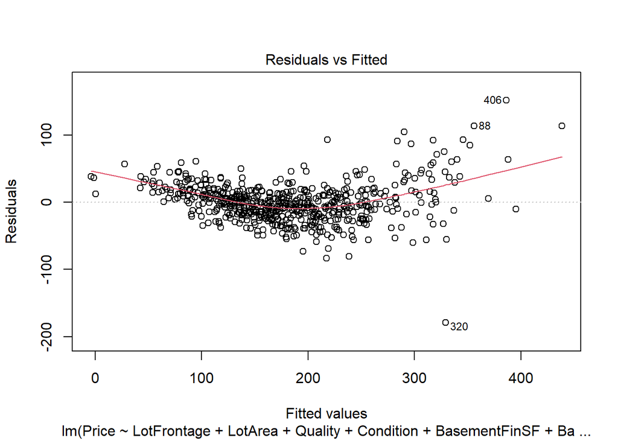

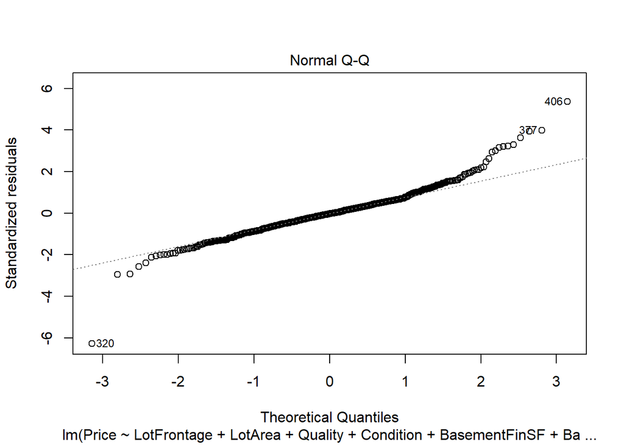

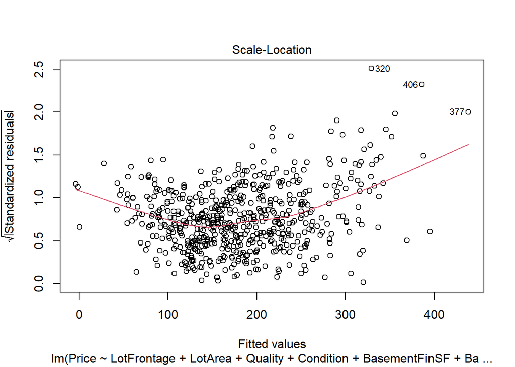

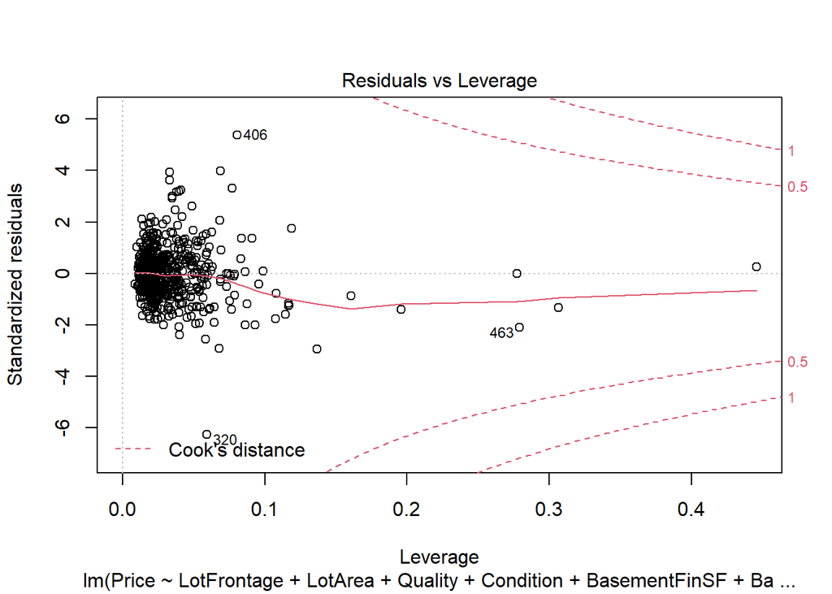

```r
plot(Ames)
```

- With the numerical variables in the dataset, R^2 is 0.8487, hence roughly 85% of the data is explained.

```r
vif(Ames)
```

```
##     LotFrontage         LotArea         Quality       Condition   BasementFinSF
##        1.099754        1.180547        2.571154        1.188768        3.798558
## BasementUnFinSF         FirstSF        SecondSF   BasementFBath   BasementHBath
##        3.435426        3.556326        3.849100        2.156316        1.159904
##        FullBath        HalfBath         Bedroom      Fireplaces        GarageSF
##        2.493375        1.984103        1.801298        1.581352        1.736276
##      WoodDeckSF     OpenPorchSF EnclosedPorchSF   ScreenPorchSF
##        1.181585        1.184168        1.233239        1.095330
```

```r
# hist.normal(Ames$residuals)
```

## Using All Subsets to select predictors

```r
AmesAll = regsubsets(Price~LotFrontage+LotArea+Quality+Condition+
                BasementFinSF+BasementUnFinSF+FirstSF+
                SecondSF+BasementFBath+BasementHBath+
                FullBath+HalfBath+Bedroom+Fireplaces+
                GarageSF+WoodDeckSF+OpenPorchSF+
                EnclosedPorchSF+ScreenPorchSF
              , data=Ames5, nbest = 2)
summary(AmesAll)
```

```
## Subset selection object
## Call: regsubsets.formula(Price ~ LotFrontage + LotArea + Quality +
##     Condition + BasementFinSF + BasementUnFinSF + FirstSF + SecondSF +
##     BasementFBath + BasementHBath + FullBath + HalfBath + Bedroom +
##     Fireplaces + GarageSF + WoodDeckSF + OpenPorchSF + EnclosedPorchSF +
##     ScreenPorchSF, data = Ames5, nbest = 2)
## 19 Variables  (and intercept)
##                 Forced in Forced out
## LotFrontage         FALSE      FALSE
## LotArea             FALSE      FALSE
## Quality             FALSE      FALSE
## Condition           FALSE      FALSE
## BasementFinSF       FALSE      FALSE
## BasementUnFinSF     FALSE      FALSE
## FirstSF             FALSE      FALSE
## SecondSF            FALSE      FALSE
## BasementFBath       FALSE      FALSE
## BasementHBath       FALSE      FALSE
## FullBath            FALSE      FALSE
## HalfBath            FALSE      FALSE
## Bedroom             FALSE      FALSE
## Fireplaces          FALSE      FALSE
## GarageSF            FALSE      FALSE
## WoodDeckSF          FALSE      FALSE
## OpenPorchSF         FALSE      FALSE
## EnclosedPorchSF     FALSE      FALSE
## ScreenPorchSF       FALSE      FALSE
## 2 subsets of each size up to 8
## Selection Algorithm: exhaustive
##          LotFrontage LotArea Quality Condition BasementFinSF BasementUnFinSF
## 1  ( 1 ) " "         " "     "*"     " "       " "           " "
## 1  ( 2 ) " "         " "     " "     " "       " "           " "
## 2  ( 1 ) " "         " "     "*"     " "       " "           " "
## 2  ( 2 ) " "         " "     "*"     " "       " "           " "
## 3  ( 1 ) " "         " "     "*"     " "       " "           " "
## 3  ( 2 ) " "         " "     "*"     " "       " "           " "
## 4  ( 1 ) " "         " "     "*"     " "       "*"           " "
## 4  ( 2 ) " "         " "     "*"     " "       " "           " "
## 5  ( 1 ) " "         " "     "*"     " "       "*"           " "
## 5  ( 2 ) " "         "*"     "*"     " "       "*"           " "
```

[output cut: 42 more lines]

```
## 1  ( 2 ) " "
## 2  ( 1 ) " "
## 2  ( 2 ) " "
## 3  ( 1 ) " "
## 3  ( 2 ) " "
## 4  ( 1 ) " "
## 4  ( 2 ) " "
## 5  ( 1 ) " "
## 5  ( 2 ) " "
## 6  ( 1 ) " "
## 6  ( 2 ) " "
## 7  ( 1 ) " "
## 7  ( 2 ) " "
## 8  ( 1 ) " "
## 8  ( 2 ) " "
```

```r
ShowSubsets(AmesAll)
```

```
##          LotFrontage LotArea Quality Condition BasementFinSF BasementUnFinSF
## 1  ( 1 )                           *
## 1  ( 2 )
## 2  ( 1 )                           *
## 2  ( 2 )                           *
## 3  ( 1 )                           *
## 3  ( 2 )                           *
## 4  ( 1 )                           *                       *
## 4  ( 2 )                           *
## 5  ( 1 )                           *                       *
## 5  ( 2 )                   *       *                       *
## 6  ( 1 )                   *       *                       *
## 6  ( 2 )           *               *                       *
## 7  ( 1 )           *       *       *                       *
## 7  ( 2 )                   *       *                       *
```

[output cut: 53 more lines]

- The smallest Cp was 45.67
- Predictors: LotFrontage + LotArea + Quality + BasementFinSF + FirstSF + SecondSF + GarageSF + OpenPorchSF

```r
modAmes1 = lm(Price~LotFrontage + LotArea + Quality + BasementFinSF + FirstSF + SecondSF + GarageSF + OpenPorchSF, data=Ames5)
summary(modAmes1)
```

```
##
## Call:
## lm(formula = Price ~ LotFrontage + LotArea + Quality + BasementFinSF +
##     FirstSF + SecondSF + GarageSF + OpenPorchSF, data = Ames5)
##
## Residuals:
##      Min       1Q   Median       3Q      Max
## -191.088  -16.711   -0.911   14.923  161.483
##
## Coefficients:
##                 Estimate Std. Error t value Pr(>|t|)
## (Intercept)   -1.104e+02  6.067e+00 -18.200  < 2e-16 ***
## LotFrontage    1.323e-01  3.897e-02   3.395 0.000731 ***
## LotArea        4.862e-04  1.003e-04   4.849 1.59e-06 ***
## Quality        2.589e+01  1.176e+00  22.027  < 2e-16 ***
## BasementFinSF  2.899e-02  3.127e-03   9.270  < 2e-16 ***
## FirstSF        5.821e-02  4.727e-03  12.316  < 2e-16 ***
## SecondSF       3.995e-02  3.359e-03  11.893  < 2e-16 ***
## GarageSF       5.057e-02  7.410e-03   6.825 2.18e-11 ***
## OpenPorchSF    5.887e-02  1.904e-02   3.092 0.002083 **
## ---
## Signif. codes:  0 '***' 0.001 '**' 0.01 '*' 0.05 '.' 0.1 ' ' 1
##
## Residual standard error: 30.34 on 591 degrees of freedom
## Multiple R-squared:  0.8414, Adjusted R-squared:  0.8393
## F-statistic:   392 on 8 and 591 DF,  p-value: < 2.2e-16
```

```r
# plot(modAmes1)
vif(modAmes1)
```

```
##   LotFrontage       LotArea       Quality BasementFinSF       FirstSF
##      1.043859      1.130386      1.784098      1.209725      1.968110
##      SecondSF      GarageSF   OpenPorchSF
##      1.395500      1.669701      1.138768
```

- No VIF > 5, so **Multicollinearity** shouldn’t be an issue.

## Using Backward Elimination to select predictors

```r
AmesFull = lm(Price~LotFrontage+LotArea+Quality+Condition+
                BasementFinSF+BasementUnFinSF+FirstSF+
                SecondSF+BasementFBath+BasementHBath+
                FullBath+HalfBath+Bedroom+Fireplaces+
                GarageSF+WoodDeckSF+OpenPorchSF+
                EnclosedPorchSF+ScreenPorchSF
              , data=Ames5)
MSE = (summary(AmesFull)$sigma)^2

step(AmesFull, scale=MSE, trace=FALSE)
```

```
##
## Call:
## lm(formula = Price ~ LotFrontage + LotArea + Quality + Condition +
##     BasementFinSF + BasementUnFinSF + FirstSF + SecondSF + FullBath +
##     HalfBath + Bedroom + Fireplaces + GarageSF + WoodDeckSF +
##     OpenPorchSF + EnclosedPorchSF, data = Ames5)
##
## Coefficients:
##     (Intercept)      LotFrontage          LotArea          Quality
##      -1.109e+02        1.723e-01        4.679e-04        2.225e+01
##       Condition    BasementFinSF  BasementUnFinSF          FirstSF
##       3.206e+00        3.816e-02        1.596e-02        5.058e-02
##        SecondSF         FullBath         HalfBath          Bedroom
##       3.734e-02        5.787e+00        9.146e+00       -5.455e+00
##      Fireplaces         GarageSF       WoodDeckSF      OpenPorchSF
##       5.383e+00        4.623e-02        2.325e-02        5.797e-02
## EnclosedPorchSF
##      -3.123e-02
```

- Predictors: LotFrontage + LotArea + Quality + Condition + BasementFinSF + BasementUnFinSF + FirstSF + SecondSF + FullBath + HalfBath + Bedroom + Fireplaces + GarageSF + WoodDeckSF + OpenPorchSF + EnclosedPorchSF
- Cp = 17.179

```r
modAmes2 = lm(Price ~ LotFrontage + LotArea + Quality + Condition +
    BasementFinSF + BasementUnFinSF + FirstSF + SecondSF + FullBath +
    HalfBath + Bedroom + Fireplaces + GarageSF + WoodDeckSF +
    OpenPorchSF + EnclosedPorchSF, data = Ames5)
summary(modAmes2)
```

```
##
## Call:
## lm(formula = Price ~ LotFrontage + LotArea + Quality + Condition +
##     BasementFinSF + BasementUnFinSF + FirstSF + SecondSF + FullBath +
##     HalfBath + Bedroom + Fireplaces + GarageSF + WoodDeckSF +
##     OpenPorchSF + EnclosedPorchSF, data = Ames5)
##
## Residuals:
##      Min       1Q   Median       3Q      Max
## -182.133  -16.071   -1.248   14.368  156.460
##
## Coefficients:
##                   Estimate Std. Error t value Pr(>|t|)
## (Intercept)     -1.109e+02  1.012e+01 -10.963  < 2e-16 ***
## LotFrontage      1.723e-01  3.877e-02   4.445 1.05e-05 ***
## LotArea          4.679e-04  9.850e-05   4.750 2.56e-06 ***
## Quality          2.225e+01  1.353e+00  16.441  < 2e-16 ***
## Condition        3.206e+00  1.124e+00   2.852  0.00450 **
## BasementFinSF    3.816e-02  5.028e-03   7.589 1.29e-13 ***
## BasementUnFinSF  1.596e-02  4.987e-03   3.199  0.00145 **
## FirstSF          5.058e-02  6.151e-03   8.224 1.29e-15 ***
## SecondSF         3.734e-02  5.399e-03   6.916 1.22e-11 ***
## FullBath         5.787e+00  3.325e+00   1.740  0.08230 .
## HalfBath         9.146e+00  3.351e+00   2.730  0.00653 **
## Bedroom         -5.455e+00  1.973e+00  -2.764  0.00588 **
## Fireplaces       5.383e+00  2.438e+00   2.208  0.02762 *
## GarageSF         4.623e-02  7.252e-03   6.375 3.72e-10 ***
## WoodDeckSF       2.325e-02  9.901e-03   2.348  0.01920 *
## OpenPorchSF      5.797e-02  1.880e-02   3.084  0.00214 **
## EnclosedPorchSF -3.123e-02  1.999e-02  -1.562  0.11887
## ---
## Signif. codes:  0 '***' 0.001 '**' 0.01 '*' 0.05 '.' 0.1 ' ' 1
##
## Residual standard error: 29.44 on 583 degrees of freedom
## Multiple R-squared:  0.8527, Adjusted R-squared:  0.8486
## F-statistic: 210.9 on 16 and 583 DF,  p-value: < 2.2e-16
```

```r
# plot(modAmes2)
vif(modAmes2)
```

```
##     LotFrontage         LotArea         Quality       Condition   BasementFinSF
##        1.097061        1.158470        2.510262        1.149547        3.321385
## BasementUnFinSF         FirstSF        SecondSF        FullBath        HalfBath
##        3.314696        3.538575        3.827829        2.380986        1.949575
##         Bedroom      Fireplaces        GarageSF      WoodDeckSF     OpenPorchSF
##        1.790606        1.545089        1.698365        1.171513        1.178533
## EnclosedPorchSF
##        1.220391
```

- No VIF > 5, so **Multicollinearity** shouldn’t be an issue.

## Using Forward Selection to select predictors

```r
none = lm(Price~1, data=Ames5)

step(none, scope=list(upper=AmesFull), scale=MSE, direction = "forward", trace = FALSE)
```

```
##
## Call:
## lm(formula = Price ~ Quality + FirstSF + SecondSF + BasementFinSF +
##     GarageSF + LotArea + LotFrontage + OpenPorchSF + WoodDeckSF +
##     Bedroom + BasementUnFinSF + HalfBath + Condition + FullBath +
##     Fireplaces + EnclosedPorchSF, data = Ames5)
##
## Coefficients:
##     (Intercept)          Quality          FirstSF         SecondSF
##      -1.109e+02        2.225e+01        5.058e-02        3.734e-02
##   BasementFinSF         GarageSF          LotArea      LotFrontage
##       3.816e-02        4.623e-02        4.679e-04        1.723e-01
##     OpenPorchSF       WoodDeckSF          Bedroom  BasementUnFinSF
##       5.797e-02        2.325e-02       -5.455e+00        1.596e-02
##        HalfBath        Condition         FullBath       Fireplaces
##       9.146e+00        3.206e+00        5.787e+00        5.383e+00
## EnclosedPorchSF
##      -3.123e-02
```

- Predictors: Quality + FirstSF + SecondSF + BasementFinSF + GarageSF + LotArea + LotFrontage + OpenPorchSF + WoodDeckSF + Bedroom + BasementUnFinSF + HalfBath + Condition + FullBath + Fireplaces + EnclosedPorchSF
- Cp = 17.179

```r
modAmes3 = lm(Price ~ Quality + FirstSF + SecondSF + BasementFinSF +
    GarageSF + LotArea + LotFrontage + OpenPorchSF + WoodDeckSF +
    Bedroom + BasementUnFinSF + HalfBath + Condition + FullBath +
    Fireplaces + EnclosedPorchSF, data = Ames5)
summary(modAmes3)
```

```
##
## Call:
## lm(formula = Price ~ Quality + FirstSF + SecondSF + BasementFinSF +
##     GarageSF + LotArea + LotFrontage + OpenPorchSF + WoodDeckSF +
##     Bedroom + BasementUnFinSF + HalfBath + Condition + FullBath +
##     Fireplaces + EnclosedPorchSF, data = Ames5)
##
## Residuals:
##      Min       1Q   Median       3Q      Max
## -182.133  -16.071   -1.248   14.368  156.460
##
## Coefficients:
##                   Estimate Std. Error t value Pr(>|t|)
## (Intercept)     -1.109e+02  1.012e+01 -10.963  < 2e-16 ***
## Quality          2.225e+01  1.353e+00  16.441  < 2e-16 ***
## FirstSF          5.058e-02  6.151e-03   8.224 1.29e-15 ***
## SecondSF         3.734e-02  5.399e-03   6.916 1.22e-11 ***
## BasementFinSF    3.816e-02  5.028e-03   7.589 1.29e-13 ***
## GarageSF         4.623e-02  7.252e-03   6.375 3.72e-10 ***
## LotArea          4.679e-04  9.850e-05   4.750 2.56e-06 ***
## LotFrontage      1.723e-01  3.877e-02   4.445 1.05e-05 ***
## OpenPorchSF      5.797e-02  1.880e-02   3.084  0.00214 **
## WoodDeckSF       2.325e-02  9.901e-03   2.348  0.01920 *
## Bedroom         -5.455e+00  1.973e+00  -2.764  0.00588 **
## BasementUnFinSF  1.596e-02  4.987e-03   3.199  0.00145 **
## HalfBath         9.146e+00  3.351e+00   2.730  0.00653 **
## Condition        3.206e+00  1.124e+00   2.852  0.00450 **
## FullBath         5.787e+00  3.325e+00   1.740  0.08230 .
## Fireplaces       5.383e+00  2.438e+00   2.208  0.02762 *
## EnclosedPorchSF -3.123e-02  1.999e-02  -1.562  0.11887
## ---
## Signif. codes:  0 '***' 0.001 '**' 0.01 '*' 0.05 '.' 0.1 ' ' 1
##
## Residual standard error: 29.44 on 583 degrees of freedom
## Multiple R-squared:  0.8527, Adjusted R-squared:  0.8486
## F-statistic: 210.9 on 16 and 583 DF,  p-value: < 2.2e-16
```

```r
# plot(modAmes3)
vif(modAmes3)
```

```
##         Quality         FirstSF        SecondSF   BasementFinSF        GarageSF
##        2.510262        3.538575        3.827829        3.321385        1.698365
##         LotArea     LotFrontage     OpenPorchSF      WoodDeckSF         Bedroom
##        1.158470        1.097061        1.178533        1.171513        1.790606
## BasementUnFinSF        HalfBath       Condition        FullBath      Fireplaces
##        3.314696        1.949575        1.149547        2.380986        1.545089
## EnclosedPorchSF
##        1.220391
```

- No VIF > 5, so **Multicollinearity** shouldn’t be an issue.

#### Chosen Set of Predictors:

- modAmes3
- Predictors: LotFrontage + LotArea + Quality + Condition + BasementFinSF + BasementUnFinSF + FirstSF + SecondSF + FullBath + HalfBath + Bedroom + Fireplaces + GarageSF + WoodDeckSF + OpenPorchSF + EnclosedPorchSF

# Part 2: Residual analysis for your chosen basic model

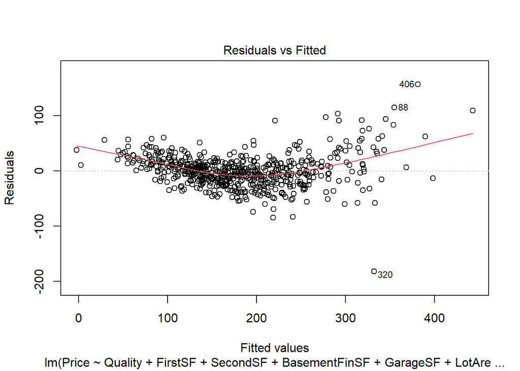

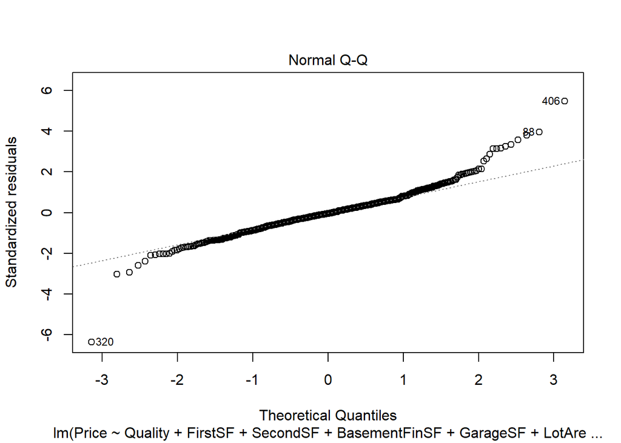

```r
plot(modAmes3, 1:2)
```

```r
summary(modAmes3)
```

```
##
## Call:
## lm(formula = Price ~ Quality + FirstSF + SecondSF + BasementFinSF +
##     GarageSF + LotArea + LotFrontage + OpenPorchSF + WoodDeckSF +
##     Bedroom + BasementUnFinSF + HalfBath + Condition + FullBath +
##     Fireplaces + EnclosedPorchSF, data = Ames5)
##
## Residuals:
##      Min       1Q   Median       3Q      Max
## -182.133  -16.071   -1.248   14.368  156.460
##
## Coefficients:
##                   Estimate Std. Error t value Pr(>|t|)
## (Intercept)     -1.109e+02  1.012e+01 -10.963  < 2e-16 ***
## Quality          2.225e+01  1.353e+00  16.441  < 2e-16 ***
## FirstSF          5.058e-02  6.151e-03   8.224 1.29e-15 ***
## SecondSF         3.734e-02  5.399e-03   6.916 1.22e-11 ***
## BasementFinSF    3.816e-02  5.028e-03   7.589 1.29e-13 ***
## GarageSF         4.623e-02  7.252e-03   6.375 3.72e-10 ***
## LotArea          4.679e-04  9.850e-05   4.750 2.56e-06 ***
## LotFrontage      1.723e-01  3.877e-02   4.445 1.05e-05 ***
## OpenPorchSF      5.797e-02  1.880e-02   3.084  0.00214 **
## WoodDeckSF       2.325e-02  9.901e-03   2.348  0.01920 *
## Bedroom         -5.455e+00  1.973e+00  -2.764  0.00588 **
## BasementUnFinSF  1.596e-02  4.987e-03   3.199  0.00145 **
## HalfBath         9.146e+00  3.351e+00   2.730  0.00653 **
## Condition        3.206e+00  1.124e+00   2.852  0.00450 **
## FullBath         5.787e+00  3.325e+00   1.740  0.08230 .
## Fireplaces       5.383e+00  2.438e+00   2.208  0.02762 *
## EnclosedPorchSF -3.123e-02  1.999e-02  -1.562  0.11887
## ---
## Signif. codes:  0 '***' 0.001 '**' 0.01 '*' 0.05 '.' 0.1 ' ' 1
##
## Residual standard error: 29.44 on 583 degrees of freedom
## Multiple R-squared:  0.8527, Adjusted R-squared:  0.8486
## F-statistic: 210.9 on 16 and 583 DF,  p-value: < 2.2e-16
```

### Conditions:

- Linearity:
  - Looking at Residual vs. Fitted plot, the red line is curved
  - Problematic
- Zero Mean:
  - Always Fit by the nature of the model
- Constant Variance:
  - Looking at Residual vs. Fitted plot, some fanning patterns towards the right
  - Problematic
- Normality
  - Looking at qq plot, the data fit this line
  - But right tail is slightly above the line, could be problematic
- Independence
  - Looking at Residual vs. Fitted plot, the curve pattern
  - Problematic

## Looking at Standardized and Studentized Residuals

```r
head(sort(modAmes3$residuals, decreasing=TRUE), n=20)
```

```
##       406        88       377       457        32       380        82       330
## 156.45973 114.95053 108.82904 103.72011  97.33149  93.59933  91.59550  91.18175
##       418       368       331       571       394       178       477        97
##  90.71266  83.16931  76.26954  72.99692  62.58662  62.10794  60.41587  58.15600
##       111         9       366       420
##  57.66423  57.64484  57.14438  56.63910
```

```r
rstandard(modAmes3)[c(406,88,377,457,32,380,82,330,418,368)]
```

```
##      406       88      377      457       32      380       82      330
## 5.489127 3.963868 3.812871 3.581949 3.346246 3.246301 3.172902 3.139275
##      418      368
## 3.154286 2.872677
```

```r
rstudent(modAmes3)[c(406,88,377,457,32,380,82,330,418,368)]
```

```
##      406       88      377      457       32      380       82      330
## 5.631880 4.014940 3.858006 3.618919 3.375953 3.273234 3.197911 3.163433
##      418      368
## 3.178821 2.890744
```

- Entry 406,88,377,457,32,380,82,330,418 are possibly influential, because both their standardized and studentized residuals are more than 3.

## Looking at Leverages

```r
# number of predictors: 16
# number of samples: 600
2*(17/600)
```

```
## [1] 0.05666667
```

```r
3*(17/600)
```

```
## [1] 0.085
```

```r
head(sort(hatvalues(modAmes3),decreasing = TRUE),20)
```

```
##        559        278        463        556        271        467        459
## 0.44183448 0.30328792 0.27387041 0.25336636 0.18795420 0.13358307 0.11358048
##        165        416        431        185        230        425        149
## 0.10967858 0.10681735 0.09770426 0.09299308 0.09165514 0.08949614 0.08762060
##        356        510        128        340        187        587
## 0.08252468 0.08137616 0.08083696 0.07814958 0.07760347 0.07423185
```

- Hat values for entry 559, 278, 463, 556, 271, 467, 459, 165, 416, 431, 185, 230, 425, 149 are high and shows those entries to have high leverage, or high potential to be influential on the model.

## Take subset of Ames5 without entries with high standardized/studentized residuals

```r
AmesRes1 <- Ames5[-c(406,88,377,457,32,380,82,330,418),]

modAmes3Res1 = lm(Price ~ Quality + FirstSF + SecondSF + BasementFinSF +
    GarageSF + LotArea + LotFrontage + OpenPorchSF + WoodDeckSF +
    Bedroom + BasementUnFinSF + HalfBath + Condition + FullBath +
    Fireplaces + EnclosedPorchSF, data = AmesRes1)
summary(modAmes3Res1)
```

```
##
## Call:
## lm(formula = Price ~ Quality + FirstSF + SecondSF + BasementFinSF +
##     GarageSF + LotArea + LotFrontage + OpenPorchSF + WoodDeckSF +
##     Bedroom + BasementUnFinSF + HalfBath + Condition + FullBath +
##     Fireplaces + EnclosedPorchSF, data = AmesRes1)
##
## Residuals:
##      Min       1Q   Median       3Q      Max
## -169.906  -15.115   -0.413   13.867   94.965
##
## Coefficients:
##                   Estimate Std. Error t value Pr(>|t|)
## (Intercept)     -9.906e+01  9.028e+00 -10.973  < 2e-16 ***
## Quality          2.171e+01  1.204e+00  18.031  < 2e-16 ***
## FirstSF          4.356e-02  5.491e-03   7.932 1.13e-14 ***
## SecondSF         3.009e-02  4.877e-03   6.169 1.30e-09 ***
## BasementFinSF    3.265e-02  4.494e-03   7.265 1.22e-12 ***
## GarageSF         4.869e-02  6.448e-03   7.551 1.71e-13 ***
## LotArea          4.227e-04  8.776e-05   4.817 1.87e-06 ***
## LotFrontage      1.678e-01  3.456e-02   4.854 1.56e-06 ***
## OpenPorchSF      4.823e-02  1.692e-02   2.851  0.00451 **
## WoodDeckSF       1.355e-02  8.860e-03   1.529  0.12681
## Bedroom         -4.370e+00  1.767e+00  -2.474  0.01367 *
## BasementUnFinSF  1.368e-02  4.428e-03   3.089  0.00210 **
## HalfBath         8.829e+00  2.985e+00   2.958  0.00322 **
## Condition        3.026e+00  1.002e+00   3.021  0.00263 **
## FullBath         7.302e+00  2.956e+00   2.470  0.01379 *
## Fireplaces       6.689e+00  2.180e+00   3.068  0.00226 **
## EnclosedPorchSF -3.458e-02  1.774e-02  -1.949  0.05176 .
## ---
## Signif. codes:  0 '***' 0.001 '**' 0.01 '*' 0.05 '.' 0.1 ' ' 1
##
## Residual standard error: 26.05 on 574 degrees of freedom
## Multiple R-squared:  0.8612, Adjusted R-squared:  0.8574
## F-statistic: 222.7 on 16 and 574 DF,  p-value: < 2.2e-16
```

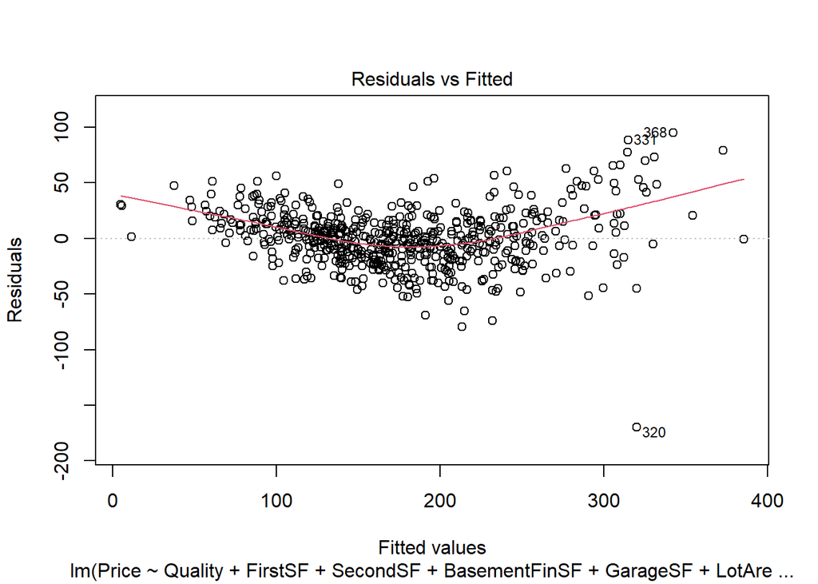

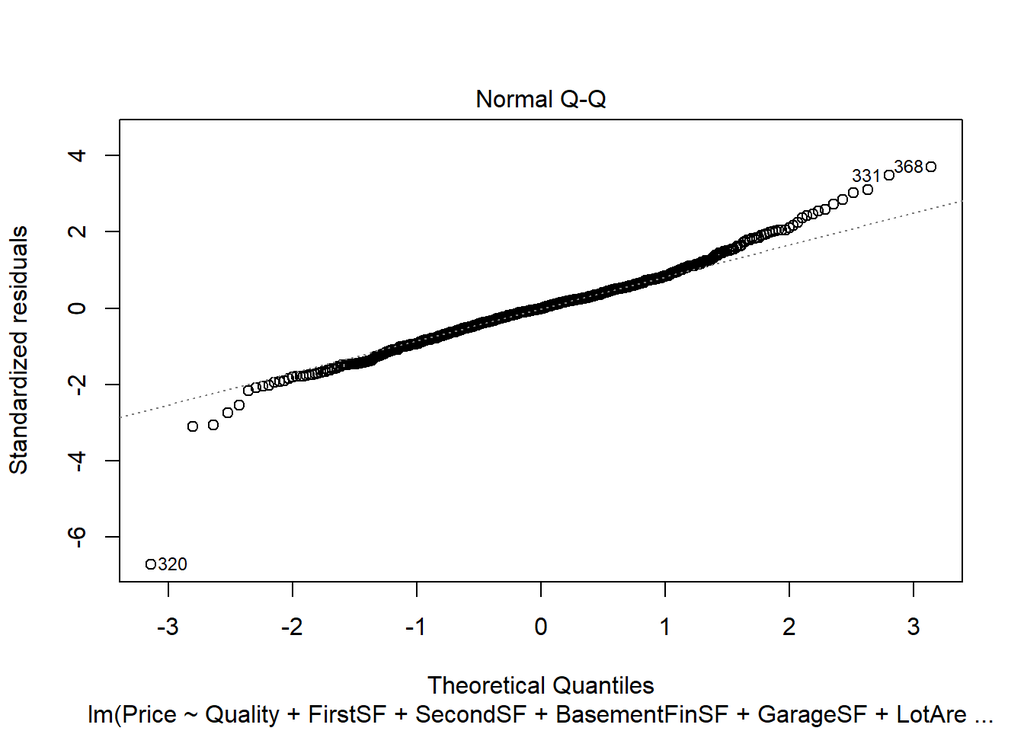

```r
plot(modAmes3Res1, 1:2)
```

## Take subset of Ames5 without entries with high leverages

```r
AmesRes2 <- Ames5[-c(559, 278, 463, 556, 271, 467, 459, 165, 416, 431, 185, 230, 425, 149),]

modAmes3Res2 = lm(Price ~ Quality + FirstSF + SecondSF + BasementFinSF +
    GarageSF + LotArea + LotFrontage + OpenPorchSF + WoodDeckSF +
    Bedroom + BasementUnFinSF + HalfBath + Condition + FullBath +
    Fireplaces + EnclosedPorchSF, data = AmesRes2)
summary(modAmes3Res2)
```

```
##
## Call:
## lm(formula = Price ~ Quality + FirstSF + SecondSF + BasementFinSF +
##     GarageSF + LotArea + LotFrontage + OpenPorchSF + WoodDeckSF +
##     Bedroom + BasementUnFinSF + HalfBath + Condition + FullBath +
##     Fireplaces + EnclosedPorchSF, data = AmesRes2)
##
## Residuals:
##      Min       1Q   Median       3Q      Max
## -192.470  -15.331   -0.999   14.038  119.549
##
## Coefficients:
##                   Estimate Std. Error t value Pr(>|t|)
## (Intercept)     -1.126e+02  1.030e+01 -10.932  < 2e-16 ***
## Quality          2.137e+01  1.424e+00  15.010  < 2e-16 ***
## FirstSF          5.181e-02  7.066e-03   7.332 7.81e-13 ***
## SecondSF         3.726e-02  5.536e-03   6.729 4.17e-11 ***
## BasementFinSF    3.738e-02  5.362e-03   6.971 8.75e-12 ***
## GarageSF         4.302e-02  7.614e-03   5.650 2.54e-08 ***
## LotArea          1.276e-03  2.942e-04   4.337 1.71e-05 ***
## LotFrontage      1.479e-01  3.899e-02   3.795 0.000164 ***
## OpenPorchSF      7.508e-02  2.063e-02   3.639 0.000299 ***
## WoodDeckSF       3.122e-02  1.090e-02   2.863 0.004349 **
## Bedroom         -6.809e+00  2.013e+00  -3.383 0.000767 ***
## BasementUnFinSF  1.554e-02  5.331e-03   2.915 0.003694 **
## HalfBath         8.458e+00  3.490e+00   2.423 0.015683 *
## Condition        3.450e+00  1.132e+00   3.047 0.002415 **
## FullBath         7.613e+00  3.401e+00   2.238 0.025589 *
## Fireplaces       5.657e+00  2.430e+00   2.328 0.020254 *
## EnclosedPorchSF -2.989e-02  2.024e-02  -1.477 0.140303
## ---
## Signif. codes:  0 '***' 0.001 '**' 0.01 '*' 0.05 '.' 0.1 ' ' 1
##
## Residual standard error: 28.73 on 569 degrees of freedom
## Multiple R-squared:  0.8586, Adjusted R-squared:  0.8546
## F-statistic: 215.9 on 16 and 569 DF,  p-value: < 2.2e-16
```

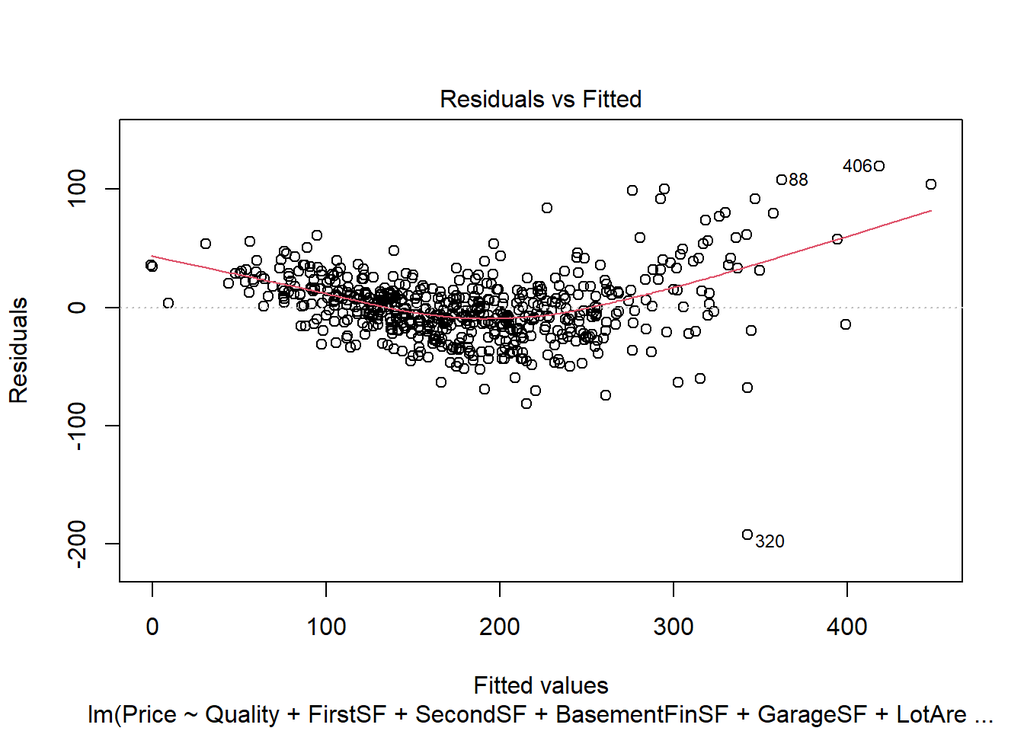

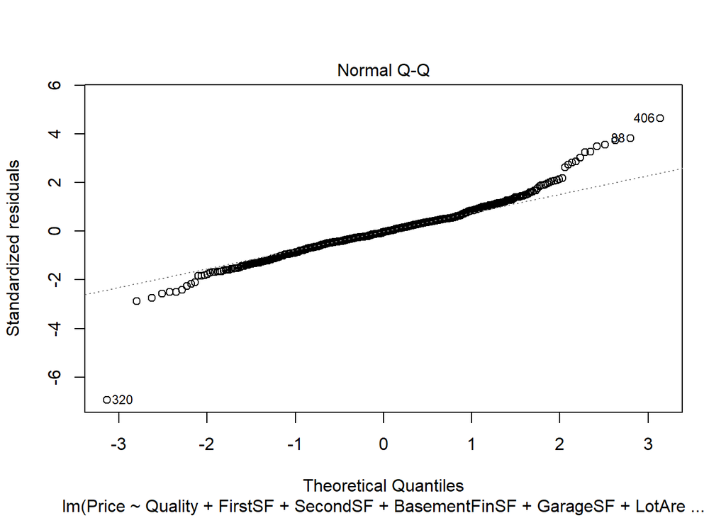

```r
plot(modAmes3Res2, 1:2)
```

- After excluding entries with high leverage, R^2 increased from 0.8486 to 0.8546, and now only *EnclosedPorchSF* has an insignificant p-value. Linearity conditions wise, the problems with Linearity, Constant Variance and Independence persist. Worth noted, the model with high residuals excluded is more effective due to its higher R^2 value.

## Take subset of Ames5 without entries with high residuals or leverage

```r
AmesRes3 <- Ames5[-c(406,88,377,457,32,380,82,330,418, 559, 278, 463, 556, 271, 467, 459, 165, 416, 431, 185, 230, 425, 149),]

modAmes3Res3 = lm(Price ~ Quality + FirstSF + SecondSF + BasementFinSF +
    GarageSF + LotArea + LotFrontage + OpenPorchSF + WoodDeckSF +
    Bedroom + BasementUnFinSF + HalfBath + Condition + FullBath +
    Fireplaces + EnclosedPorchSF, data = AmesRes3)
summary(modAmes3Res3)
```

```
##
## Call:
## lm(formula = Price ~ Quality + FirstSF + SecondSF + BasementFinSF +
##     GarageSF + LotArea + LotFrontage + OpenPorchSF + WoodDeckSF +
##     Bedroom + BasementUnFinSF + HalfBath + Condition + FullBath +
##     Fireplaces + EnclosedPorchSF, data = AmesRes3)
##
## Residuals:
##      Min       1Q   Median       3Q      Max
## -172.453  -14.811   -0.574   13.635   95.137
##
## Coefficients:
##                   Estimate Std. Error t value Pr(>|t|)
## (Intercept)     -9.743e+01  9.298e+00 -10.479  < 2e-16 ***
## Quality          2.067e+01  1.277e+00  16.190  < 2e-16 ***
## FirstSF          4.643e-02  6.360e-03   7.300 9.95e-13 ***
## SecondSF         3.063e-02  5.035e-03   6.084 2.18e-09 ***
## BasementFinSF    3.266e-02  4.813e-03   6.785 2.96e-11 ***
## GarageSF         4.841e-02  6.838e-03   7.080 4.34e-12 ***
## LotArea          5.151e-04  2.877e-04   1.790  0.07398 .
## LotFrontage      1.538e-01  3.508e-02   4.383 1.40e-05 ***
## OpenPorchSF      6.317e-02  1.880e-02   3.361  0.00083 ***
## WoodDeckSF       1.970e-02  9.866e-03   1.997  0.04633 *
## Bedroom         -4.867e+00  1.822e+00  -2.671  0.00779 **
## BasementUnFinSF  1.364e-02  4.765e-03   2.863  0.00435 **
## HalfBath         8.735e+00  3.134e+00   2.787  0.00549 **
## Condition        2.986e+00  1.017e+00   2.936  0.00346 **
## FullBath         8.563e+00  3.046e+00   2.811  0.00511 **
## Fireplaces       7.002e+00  2.190e+00   3.197  0.00147 **
## EnclosedPorchSF -3.503e-02  1.808e-02  -1.937  0.05321 .
## ---
## Signif. codes:  0 '***' 0.001 '**' 0.01 '*' 0.05 '.' 0.1 ' ' 1
##
## Residual standard error: 25.6 on 560 degrees of freedom
## Multiple R-squared:  0.8639, Adjusted R-squared:   0.86
## F-statistic: 222.1 on 16 and 560 DF,  p-value: < 2.2e-16
```

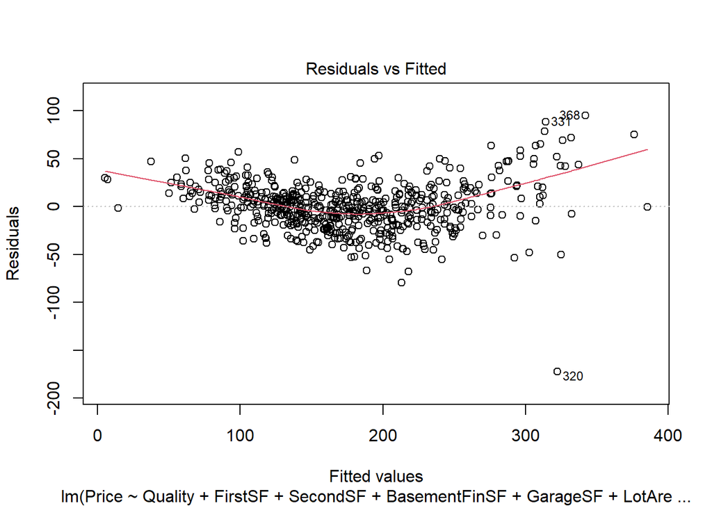

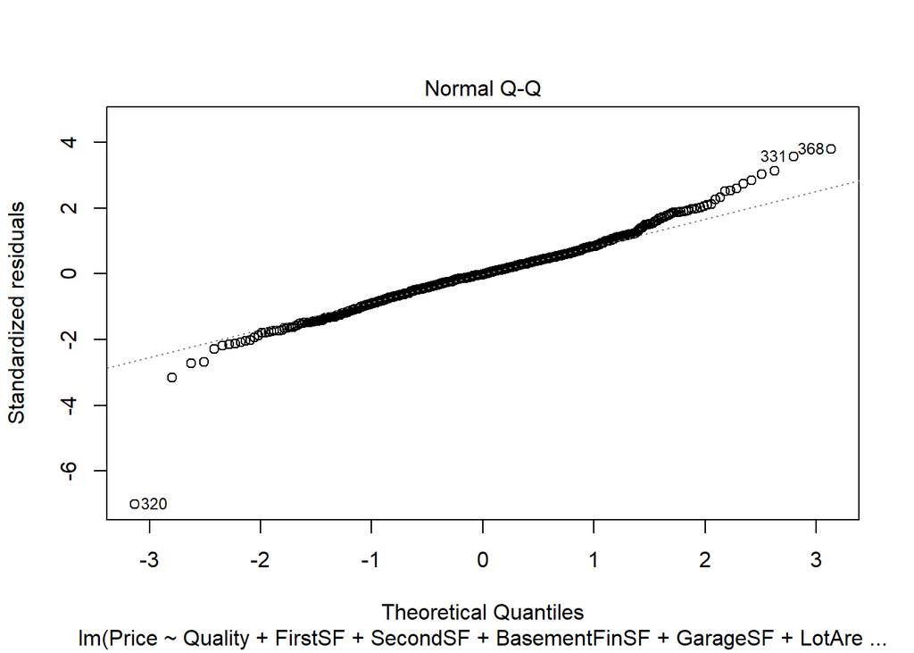

```r
plot(modAmes3Res3, 1:2)
```